# importing and investigate the dataset

# Model Feature Importance

```python
DT.feature_importances_
```

```
array([0.14362512, 0.03075482, 0.02792675, 0.02731208, 0.62534171,
       0.01803547, 0.09472027, 0.02940269, 0.0028811 ])
```

```python
importance_df = pd.DataFrame({
  'feature': X_train.columns,
  'importance': DT.feature_importances_
}).sort_values('importance', ascending=False)
```

```python
importance_df
```

|  | feature | importance |
| --- | --- | --- |
| 4 | GR | 0.625342 |
| 0 | DEPTH_MD | 0.143625 |
| 6 | DTC | 0.094720 |
| 1 | CALI | 0.030755 |
| 7 | ROP | 0.029403 |
| 2 | RDEP | 0.027927 |
| 3 | RHOB | 0.027312 |
| 5 | PEF | 0.018035 |
| 8 | MUDWEIGHT | 0.002881 |

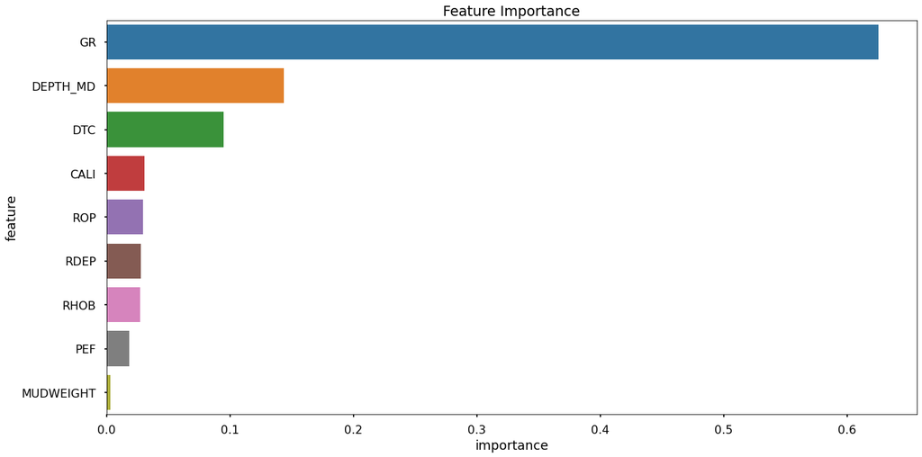

```python
plt.figure(figsize=(20,10))
plt.title('Feature Importance')
sns.barplot(data=importance_df, x='importance', y='feature');
```

## Model Evaluation

```
Decision Tree Accuracy 94.87 %:
```

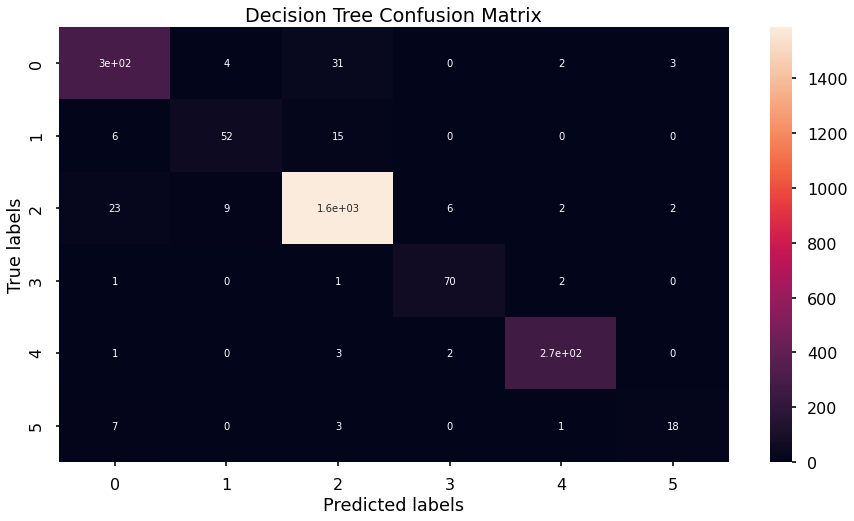

```python
from sklearn.metrics import confusion_matrix
from sklearn.metrics import classification_report
from sklearn import metrics

DT_y_predict = DT.predict(X2_test)
DT_cm = confusion_matrix(y_true=y2_test, y_pred=DT_y_predict)
print("Decision Tree Accuracy {:.2f} %:". format(metrics.accuracy_score(y2_test, DT_y_predict)*100))

# plot Confusion Matrix
plt.figure(figsize = (15,8))
ax= plt.subplot()
sns.heatmap(DT_cm, annot=True, ax = ax, cbar=True)

# labels, title and ticks
ax.set_xlabel('Predicted labels')
ax.set_ylabel('True labels')
ax.set_title('Decision Tree Confusion Matrix')
plt.show();
```

```python
print(classification_report(y2_test, DT_y_predict))
```

```
              precision    recall  f1-score   support

           0       0.89      0.88      0.89       341
           1       0.80      0.71      0.75        73
           2       0.97      0.97      0.97      1629
           3       0.90      0.95      0.92        74
           5       0.97      0.98      0.98       273
           9       0.78      0.62      0.69        29

    accuracy                           0.95      2419
   macro avg       0.89      0.85      0.87      2419
weighted avg       0.95      0.95      0.95      2419
```

## HyperParameter Tunning

### Max_Depth

Max Depth: is the number of layer that decision tree can generate while learning from the training samples. limiting the maximum depth of the decision tree prevents the tree from overfitting all training samples and leads to better generalization

```python
def max_depth_error(md):
  model = DecisionTreeClassifier(max_depth=md, random_state=42)
  model.fit(X2_train, y2_train)
  train_acc = 1 - model.score(X2_train, y2_train)
  val_acc = 1 - model.score(X2_test, y2_test)
  return {'Max Depth': md, 'Training Error': train_acc, 'Test Error': val_acc}
```

```python
%%time
errors_df = pd.DataFrame([max_depth_error(md) for md in range(1, 21)])
```

```
CPU times: user 1.86 s, sys: 3.38 ms, total: 1.87 s
Wall time: 1.86 s
```

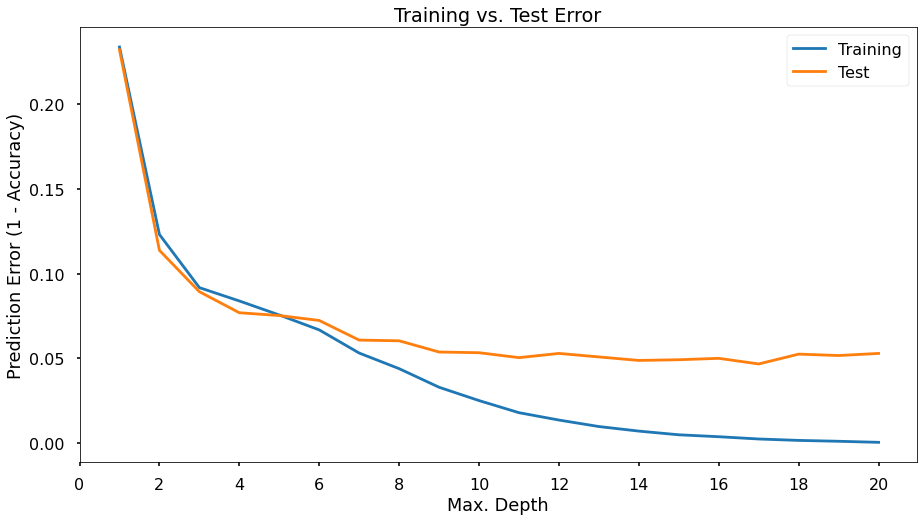

```python
plt.figure(figsize = (15,8))
plt.plot(errors_df['Max Depth'], errors_df['Training Error'])
plt.plot(errors_df['Max Depth'], errors_df['Test Error'])
plt.title('Training vs. Test Error')
plt.xticks(range(0,21, 2))
plt.xlabel('Max. Depth')
plt.ylabel('Prediction Error (1 - Accuracy)')
plt.legend(['Training', 'Test'])
```

### max_leaf_nodes

to control the size of complexity of a decision tree is to limit the number of leaf nodes. This allows branches of the tree to have varying depths.

```python
def max_leaf_nodes_error(mln):
  model = DecisionTreeClassifier(max_leaf_nodes=mln, random_state=42)
  model.fit(X2_train, y2_train)
  train_acc = 1 - model.score(X2_train, y2_train)
  test_acc = 1 - model.score(X2_test, y2_test)
  return {'max_leaf_nodes': mln, 'Training Error': train_acc, 'Test Error': test_acc}
```

```python
%%time
mln_errors_df = pd.DataFrame([max_leaf_nodes_error(mln) for mln in range(10, 200)])
```

```
CPU times: user 15.9 s, sys: 27.2 ms, total: 15.9 s
Wall time: 15.8 s
```

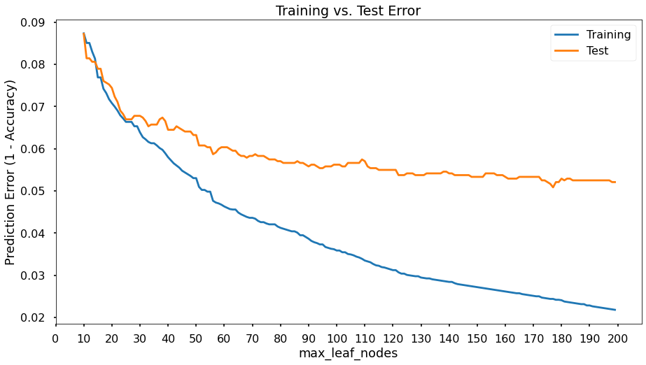

```python
plt.figure(figsize = (15,8))
plt.plot(mln_errors_df['max_leaf_nodes'], mln_errors_df['Training Error'])
plt.plot(mln_errors_df['max_leaf_nodes'], mln_errors_df['Test Error'])
plt.title('Training vs. Test Error')
plt.xticks(range(0,201, 10))
plt.xlabel('max_leaf_nodes')
plt.ylabel('Prediction Error (1 - Accuracy)')
plt.legend(['Training', 'Test']);
```

## **Please do the same exercise for minimum sample leaf**

```python
DT_m = DecisionTreeClassifier(max_leaf_nodes=25,max_depth=7,
                              min_samples_leaf=10, random_state=42).fit(X2_train, y2_train)
```